# Project -5 Modelling Compressive Strength of Concrete using Regression

## (1) Importing Python libraries

```python
import numpy as np
import pandas as pd
import matplotlib.pyplot as plt
import seaborn as sns
import matplotlib.style as style; style.use('classic')
import ipywidgets as widgets
import itertools
from scipy.stats import shapiro
from scipy import stats

from sklearn.impute import SimpleImputer
from sklearn.decomposition import PCA
from sklearn.mixture import GaussianMixture
from sklearn.preprocessing import StandardScaler, RobustScaler,MinMaxScaler, PowerTransformer, KBinsDiscretizer, PolynomialFeatures
from sklearn.feature_selection import RFE


# Modeling Library
from sklearn.model_selection import train_test_split, GridSearchCV, RandomizedSearchCV,StratifiedKFold, cross_val_score, learning_curve , cross_val_score
from sklearn.pipeline import make_pipeline,Pipeline
from sklearn.ensemble import  RandomForestRegressor, GradientBoostingRegressor, AdaBoostRegressor, ExtraTreesRegressor, BaggingRegressor, IsolationForest
from sklearn.tree import DecisionTreeRegressor
from catboost import CatBoostRegressor, Pool
import lightgbm as lgb
from sklearn.linear_model import Lasso,Ridge,LassoCV,RidgeCV,LinearRegression,ElasticNet
from sklearn.svm import SVR

from sklearn.metrics import r2_score
from sklearn.utils import resample

import warnings
warnings.filterwarnings("ignore")
import re
import random



from tqdm import tqdm
from IPython.display import clear_output,display, Markdown, Latex
import plotly.graph_objects as go
from plotly.offline import init_notebook_mode, iplot

init_notebook_mode(connected=True)


%matplotlib inline
plt.rcParams["figure.figsize"] = (15,10)
pd.set_option('display.max_colwidth', 500)



from edafunc import *
```

## (2) Data Loading

```python
df = pd.read_csv("concrete.csv")
df.head()
```

|  | cement | slag | ash | water | superplastic | coarseagg | fineagg | age | strength |
| --- | --- | --- | --- | --- | --- | --- | --- | --- | --- |
| 0 | 141.3 | 212.0 | 0.0 | 203.5 | 0.0 | 971.8 | 748.5 | 28 | 29.89 |
| 1 | 168.9 | 42.2 | 124.3 | 158.3 | 10.8 | 1080.8 | 796.2 | 14 | 23.51 |
| 2 | 250.0 | 0.0 | 95.7 | 187.4 | 5.5 | 956.9 | 861.2 | 28 | 29.22 |
| 3 | 266.0 | 114.0 | 0.0 | 228.0 | 0.0 | 932.0 | 670.0 | 28 | 45.85 |
| 4 | 154.8 | 183.4 | 0.0 | 193.3 | 9.1 | 1047.4 | 696.7 | 28 | 18.29 |

#### Observation:

1. Need to interpret `slag` as `blast`

## (3) Descriptive Analytics

```python
display(Markdown(f"#### The data contains {df.shape[0]} rows and {df.shape[1]} columns"))
```

The data contains 1030 rows and 9 columns

```python
df.info(verbose=True)
```

```
<class 'pandas.core.frame.DataFrame'>
RangeIndex: 1030 entries, 0 to 1029
Data columns (total 9 columns):
 #   Column        Non-Null Count  Dtype
---  ------        --------------  -----
 0   cement        1030 non-null   float64
 1   slag          1030 non-null   float64
 2   ash           1030 non-null   float64
 3   water         1030 non-null   float64
 4   superplastic  1030 non-null   float64
 5   coarseagg     1030 non-null   float64
 6   fineagg       1030 non-null   float64
 7   age           1030 non-null   int64
 8   strength      1030 non-null   float64
dtypes: float64(8), int64(1)
memory usage: 72.5 KB
```

#### All variables in the data set are numeric with data types as either `float64` or `int64`

```python
%run edafunc.py
data_describe(df,ret=True)
```

|  | count | mean | std | min | 25% | 50% | 75% | max | Median | Range | IQR | Kurtosis | Skewness | MeanAbsoluteDeviation | Num_Outliers |
| --- | --- | --- | --- | --- | --- | --- | --- | --- | --- | --- | --- | --- | --- | --- | --- |
| cement | 1030.0 | 281.167864 | 104.506364 | 102.00 | 192.375 | 272.900 | 350.000 | 540.0 | 272.900 | 438.00 | 157.625 | -0.5207 | 0.5095 | 86.7789 | 0 |
| slag | 1030.0 | 73.895825 | 86.279342 | 0.00 | 0.000 | 22.000 | 142.950 | 359.4 | 22.000 | 359.40 | 142.950 | -0.5082 | 0.8007 | 76.9266 | 2 |
| ash | 1030.0 | 54.188350 | 63.997004 | 0.00 | 0.000 | 0.000 | 118.300 | 200.1 | 0.000 | 200.10 | 118.300 | -1.3287 | 0.5374 | 60.4193 | 0 |
| water | 1030.0 | 181.567282 | 21.354219 | 121.80 | 164.900 | 185.000 | 192.000 | 247.0 | 185.000 | 125.20 | 27.100 | 0.1221 | 0.0746 | 16.9195 | 9 |
| superplastic | 1030.0 | 6.204660 | 5.973841 | 0.00 | 0.000 | 6.400 | 10.200 | 32.2 | 6.400 | 32.20 | 10.200 | 1.4113 | 0.9072 | 4.9202 | 10 |
| coarseagg | 1030.0 | 972.918932 | 77.753954 | 801.00 | 932.000 | 968.000 | 1029.400 | 1145.0 | 968.000 | 344.00 | 97.400 | -0.5990 | -0.0402 | 62.8046 | 0 |
| fineagg | 1030.0 | 773.580485 | 80.175980 | 594.00 | 730.950 | 779.500 | 824.000 | 992.6 | 779.500 | 398.60 | 93.050 | -0.1022 | -0.2530 | 61.8813 | 5 |
| age | 1030.0 | 45.662136 | 63.169912 | 1.00 | 7.000 | 28.000 | 56.000 | 365.0 | 28.000 | 364.00 | 49.000 | 12.1690 | 3.2692 | 39.1203 | 59 |
| strength | 1030.0 | 35.817961 | 16.705742 | 2.33 | 23.710 | 34.445 | 46.135 | 82.6 | 34.445 | 80.27 | 22.425 | -0.3137 | 0.4170 | 13.4607 | 4 |

#### Identify the target variable and create maps/inverse maps

```python
target_var = 'strength'
```

## (4) Data Cleansing

```python
%run edafunc.py
find_na(df)
```

|  | NANs | Zeros | Negatives |
| --- | --- | --- | --- |
| cement | 0 | 0 | 0 |
| slag | 0 | 471 | 0 |
| ash | 0 | 566 | 0 |
| water | 0 | 0 | 0 |
| superplastic | 0 | 379 | 0 |
| coarseagg | 0 | 0 | 0 |
| fineagg | 0 | 0 | 0 |
| age | 0 | 0 | 0 |
| strength | 0 | 0 | 0 |

#### Observations :

1. There are no NaNs.
2. Zero values are seen in `slag`, `ash` and `superplastic` variables. Need to perform a bivariate analysis to understand if `0` value is genuine.
3. No Negative values are found.

```python
%run edafunc.py
cat_var_list,cont_var_list,cats_df1= create_variable_list(df,3,stats=True)
cats_df1
```

|  | Variable | Type | Categorical_Class | Uniques | N-Uniques |
| --- | --- | --- | --- | --- | --- |
| 0 | cement | Numeric | NaN | NaN | 278 |
| 1 | slag | Numeric | NaN | NaN | 185 |
| 2 | ash | Numeric | NaN | NaN | 156 |
| 3 | water | Numeric | NaN | NaN | 195 |
| 4 | superplastic | Numeric | NaN | NaN | 111 |
| 5 | coarseagg | Numeric | NaN | NaN | 284 |
| 6 | fineagg | Numeric | NaN | NaN | 302 |
| 7 | age | Numeric | NaN | NaN | 14 |
| 8 | strength | Numeric | NaN | NaN | 845 |

## (5) Exploratory Data Analysis

### (5.1) Univariate Data Analysis

Univariate Analysis

`CEMENT` </br>

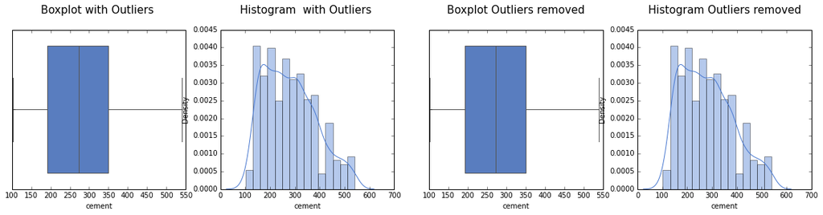

`SLAG` </br>

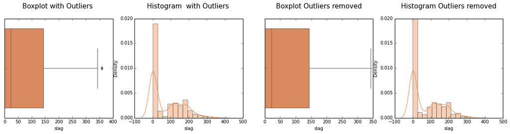

`ASH` </br>

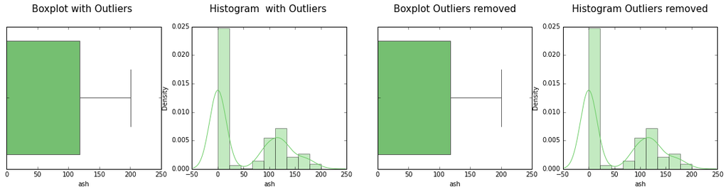

`WATER` </br>

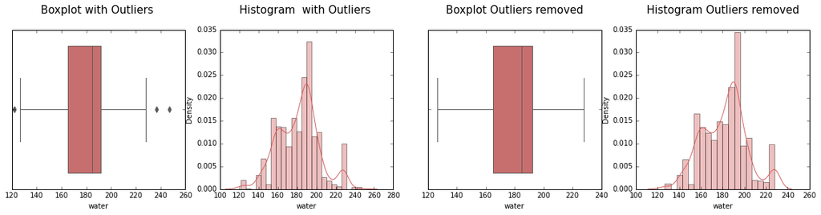

`SUPERPLASTIC` </br>

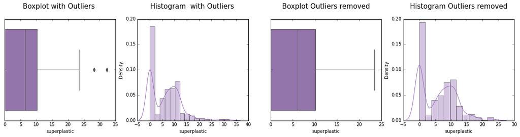

`COARSEAGG` </br>

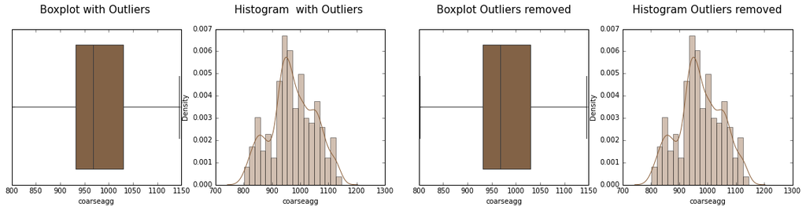

`FINEAGG` </br>

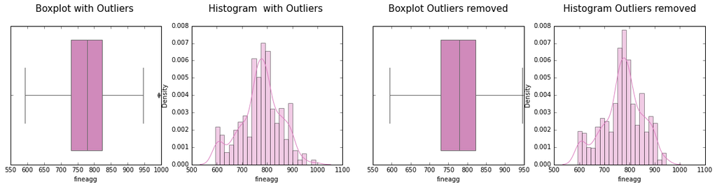

`AGE` </br>

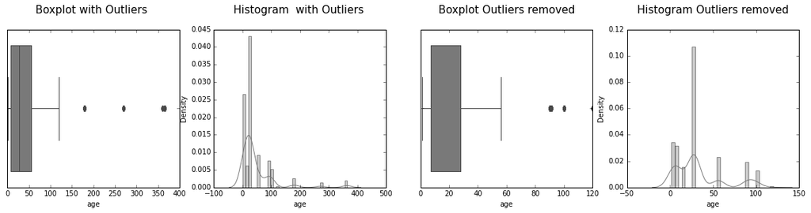

`STRENGTH` </br>

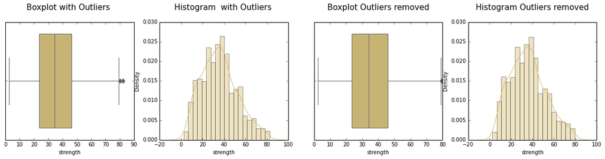

```python
sncp_c1 = sns.color_palette("muted", 40)

num_cols=4

display(Markdown("# <center><u>Univariate Analysis</u></center>\n\n"))
for color,index in enumerate((range(0,len(cont_var_list)))):
    fig, ax = plt.subplots(1,num_cols,figsize=(20,4))

    display(Markdown(f"## <center>`{cont_var_list[index].upper()}`</center></br>"))

    sns.boxplot(df[cont_var_list[index]],color=sncp_c1[color],ax=ax[0]);
    ax[0].set_title(f'Boxplot with Outliers \n',{'fontsize':15})

    sns.distplot(df[cont_var_list[index]],kde=True,color=sncp_c1[color],ax=ax[1]);
    ax[1].set_title(f'Histogram  with Outliers \n',{'fontsize':15})

    ol_temp = sp.outliers_iqr(df[cont_var_list[index]])

    sns.boxplot(ol_temp,color=sncp_c1[color],ax=ax[2]);
    ax[2].set_title(f'Boxplot Outliers removed\n',{'fontsize':15})

    sns.distplot(ol_temp,color=sncp_c1[color],ax=ax[3]);
    ax[3].set_title(f'Histogram Outliers removed\n',{'fontsize':15})
    plt.show()
```

#### Observations:

1. By visual inspection there is no significant difference with or without outliers.
2. However, There seems to be small impact of outlier removal to `age`.
3. It also appears that none of the variables have a `Normal` distribution. Lets verify it through `Shapiro-Wilkinson` test

```python
%run edafunc.py
display(get_Normality_Check(df));
print("\nNote:\n  Bin'd variables are not displayed in this chart\n")
```

| Features | Normality | P-Value |
| --- | --- | --- |
| cement | No | 2.080807e-16 |
| slag | No | 5.796104e-33 |
| ash | No | 4.134551e-36 |
| water | No | 1.464221e-10 |
| superplastic | No | 9.066004e-29 |
| coarseagg | No | 8.352464e-10 |
| fineagg | No | 1.843376e-10 |
| age | No | 7.707142e-44 |
| strength | No | 9.010161e-11 |

```
Note:
  Bin'd variables are not displayed in this chart
```

#### Observations:

1. Yes. None of the variables have a normal distribution.